# Trabajo Práctico Individual Nº 3

Regresión Logística - Adult Census Income USA

Autor/a

Francesca Nonide

Fecha de publicación

2026-06-14

# Preparación, carga y limpieza de datos

### Librerias

```r
if (!require("pacman")) install.packages("pacman")
pacman::p_load(
  tidyverse,
  here,
  broom,
  ggplot2,
  marginaleffects,
  patchwork,
  kableExtra)
```

### Creo carpeta “data” y cargo datos

```r
data_dir <- here("TP3", "data")

#si no existe la carpeta que se cree
if (!dir.exists(data_dir)) {
  dir.create(data_dir)
  message("Creando carpeta:", data_dir)
  } else {
  message("La carpeta ya existe")}
```

```
La carpeta ya existe
```

```r
#cargo los datos
USA <- read_csv(here("TP3", "data", "adult_census_USA.csv"))
```

Objetivo: modelar la probabilidad de que un ciudadano tenga ingresos superiores a los $50,000 (dólares) anuales (variable objetivo dicotómica: >50K vs <=50K), utilizando predictores demográficos y laborales

- Qué factores sociodemográficos y laborales determinan que un ciudadano pertenezca al estrato de altos ingresos
  - H1: educación alta (educacion alta mayores ingresos). Var: education
  - H2: género (hombres mayores ingresos). Var: sex
  - H3: pais nativo (si es de USA mayores ingresos). Var: native_country
  - H4: raza (si White, mayores ingresos). Var: race
  - H4: edad (a mayor edad, mayores ingresos). Var: age
  - H5: horas trabajadas (a más horas, mayores ingresos pero el efecto es distinto segun el sexo). Var hours_per_week

### Datos Balanceados y variables

```r
glimpse(USA)
```

```
Rows: 15,766
Columns: 14
$ age            <dbl> 28, 37, 49, 52, 31, 42, 37, 30, 38, 43, 40, 35, 43, 56,…
$ workclass      <chr> "Private", "Private", "Private", "Self-emp-not-inc", "P…
$ education      <chr> "Bachelors", "Masters", "9th", "HS-grad", "Masters", "B…
$ education_num  <dbl> 13, 14, 5, 9, 14, 13, 10, 13, 7, 14, 16, 5, 7, 13, 9, 1…
$ marital_status <chr> "Married-civ-spouse", "Married-civ-spouse", "Married-sp…
$ occupation     <chr> "Prof-specialty", "Exec-managerial", "Other-service", "…
$ relationship   <chr> "Wife", "Wife", "Not-in-family", "Husband", "Not-in-fam…
$ race           <chr> "Black", "White", "Black", "White", "White", "White", "…
$ sex            <chr> "Female", "Female", "Female", "Male", "Female", "Male",…
$ capital_gain   <dbl> 0, 0, 0, 0, 14084, 5178, 0, 0, 0, 0, 0, 0, 0, 0, 0, 0, …
$ capital_loss   <dbl> 0, 0, 0, 0, 0, 0, 0, 0, 0, 0, 0, 0, 2042, 0, 0, 0, 0, 0…
$ hours_per_week <dbl> 40, 40, 16, 45, 50, 40, 80, 40, 50, 45, 60, 40, 40, 40,…
$ native_country <chr> "Cuba", "United-States", "Jamaica", "United-States", "U…
$ income         <chr> "<=50K", "<=50K", "<=50K", ">50K", ">50K", ">50K", ">50…
```

```r
table(USA["native_country"])
```

```
native_country
                  Cambodia                     Canada
                        10                         62
                     China                   Columbia
                        39                         21
                      Cuba         Dominican-Republic
                        56                         20
                   Ecuador                El-Salvador
                        15                         40
                   England                     France
                        49                         14
                   Germany                     Greece
                        79                         14
                 Guatemala                      Haiti
                        35                         15
        Holand-Netherlands                   Honduras
                         1                          5
                      Hong                    Hungary
                        10                          7
                     India                       Iran
                        63                         25
                   Ireland                      Italy
                         8                         37
                   Jamaica                      Japan
                        35                         36
                      Laos                     Mexico
                         6                        253
                 Nicaragua Outlying-US(Guam-USVI-etc)
                        12                          4
                      Peru                Philippines
                        18                         97
                    Poland                   Portugal
                        30                         16
               Puerto-Rico                   Scotland
                        41                          7
                     South                     Taiwan
                        39                         25
                  Thailand            Trinadad&Tobago
                        10                          8
             United-States                    Vietnam
                     14468                         28
                Yugoslavia
                         8
```

```r
table(USA["race"])
```

```
race
Amer-Indian-Eskimo Asian-Pac-Islander              Black              Other
               114                457               1252                 87
             White
             13856
```

```r
table(USA["education"])
```

```
education
        10th         11th         12th      1st-4th      5th-6th      7th-8th
         320          418          153           56          120          240
         9th   Assoc-acdm    Assoc-voc    Bachelors    Doctorate      HS-grad
         182          555          686         3184          318         4642
     Masters    Preschool  Prof-school Some-college
        1194           16          451         3231
```

```r
table(USA["sex"])
```

```
sex
Female   Male
  4253  11513
```

```r
table(USA["income"])
```

```
income
<=50K  >50K
 8258  7508
```

```r
datos_usa <- USA %>%
  mutate(
    #ifelse (condicion, valor_true, valor_false)
    #INGRESO
    ingreso = factor(income, levels = c("<=50K", ">50K")),
    #binaria: ingreso alto 1 sino 0
    #ingreso_alto = ifelse(income == ">50K", 1, 0),

    #EDUCACION
    nivel_edu = case_when(
      education %in% c("Preschool", "1st-4th", "5th-6th", "7th-8th",
                       "9th", "10th", "11th", "12th") ~ "baja",
      education %in% c("HS-grad", "Some-college","Assoc-voc","Assoc-acdm") ~ "media",
      education %in% c("Bachelors", "Masters", "Prof-school", "Doctorate") ~ "alta"),

    nivel_edu = factor(nivel_edu, levels = c("media", "baja", "alta")),

   #PAIS NATIVO
   native_country = if_else(native_country == "United-States",
                             "United-States", "Other"),
   native_country = factor(native_country, levels = c("Other", "United-States")),

   #RAZA
   race = if_else(race == "White", "White", "Other"),
   race = factor(race, levels = c("Other", "White")),

   #GENERO
   sex = factor(sex, levels = c("Female", "Male")), #female como ref
  )

#Comprobamos el balance de nuestra variable objetivo
message("Distribución de la variable objetivo:")
```

```
Distribución de la variable objetivo:
```

```r
print(table(datos_usa$ingreso))
```

```
<=50K  >50K
 8258  7508
```

```r
#verificar si quedo bien
message("Verificamos el nuevo dataframe:")
```

```
Verificamos el nuevo dataframe:
```

```r
datos_usa %>% select(nivel_edu, native_country, race, sex, income) %>%
  summary()
```

```
 nivel_edu          native_country     race           sex
 media:9114   Other        : 1298   Other: 1910   Female: 4253
 baja :1505   United-States:14468   White:13856   Male  :11513
 alta :5147
    income
 Length:15766
 Class :character
 Mode  :character
```

Vemos que los datos se encuentran balanceados ya que hay 8258 observaciones con ingresos menores o iguales a 50k y 7508 observaciones con ingresos mayores a 50k (ingresos altos).

Clasificamos nivel educativo según la estructura formal del sistema educativo. Se categoriza como educacion baja a quienes no completaron la educacion secundaria (preschool a 12th grade), como categoria media a quienes finalizaron el secundario e hicieron algun nivel terciario (desde HS-grad, some-college, Assoc-voc, Assoc-acdm) y educacion alta a quines obtuvieron un titulo universitario de grado o posgrado (bachelors, masters, Prof-school, Doctorate). Al evaluar la distribucion de nivel educativo, vemos que la categoria baja solo concentra 1505 observaciones, mientras que la media 9114 y la alta 5147. Dado que la categoria de referencia en un modelo *logit* es con la que vamos a comparar las demas, utilizar el nivel educativo bajo como referencia implicaria estimaciones menos estables. Por lo msimo, definimos media como categoria de referencia al ser de las mas representativas de la poblacion.

Respecto a la variable native_country, fue simplificada a dos categorias, quedando 14468 observaciones para observaciones estadounidenses y 1298 para otras nacionalidades. La variable race tambien fue simplificada, quedando en 13856 observaciones para blancos y 1910 observaciones de otra raza (afroamericanos, asiaticos, entre otros)

# Analisis exploratorio y Decisiones de transformacion

**Nivel Educativo vs income (Gráfico de Barras Proporcional)**

```r
#definimos paleta de colores consistentes para todo el notebook
message("Paleta de colores creada")
```

```
Paleta de colores creada
```

```r
paleta_income <- c(">50K" = "#458b00", "<=50K" = "#B2182B")

# Comprobamos la distribución de ingreso según nivel educativo
message("Distribución de la variable objetivo según nivel educativo:")
```

```
Distribución de la variable objetivo según nivel educativo:
```

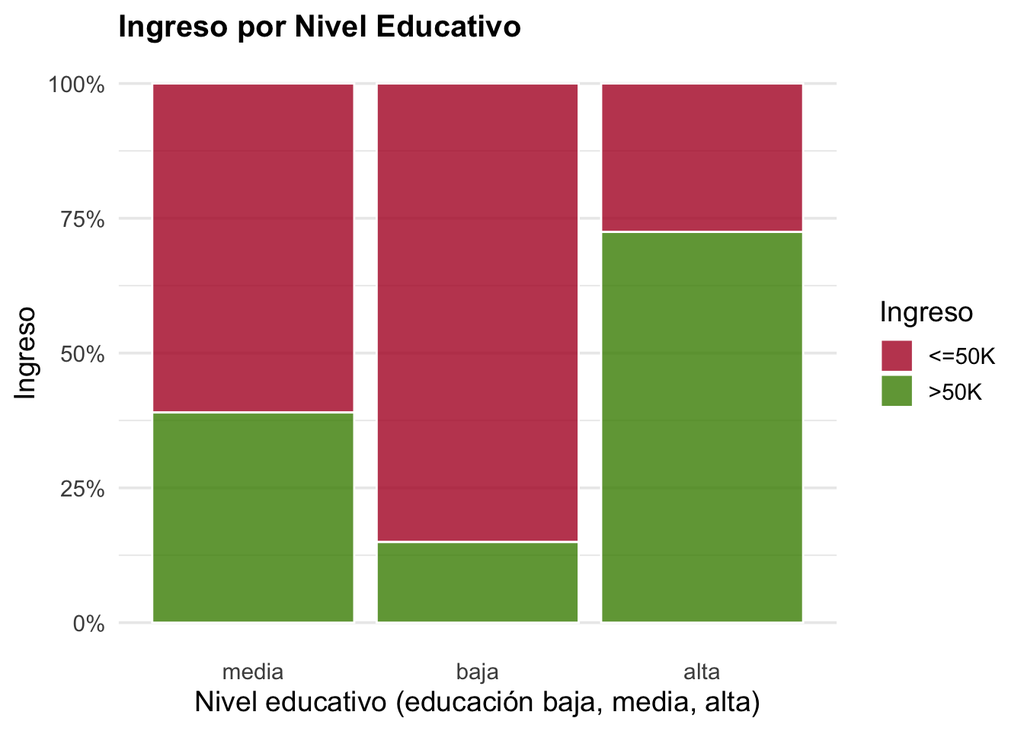

```r
vis_edu <- datos_usa %>%
  ggplot(aes(x = nivel_edu, fill = ingreso)) +
  geom_bar(position = "fill", alpha = 0.8, color = "white") +
  scale_fill_manual(values = paleta_income, name = "Ingreso") +
  scale_y_continuous(labels = scales::label_percent()) +
  labs(
    title = "Ingreso por Nivel Educativo",
    x = "Nivel educativo (educación baja, media, alta)",
    y = "Ingreso"
  ) +
  theme_minimal(base_size = 14) +
  theme(
    plot.title = element_text(face = "bold", size = 15),
    panel.grid.major.x = element_blank() # Limpiamos la grilla vertical en barras
  )
vis_edu
```

**Sexo vs income (Gráfico de Barras Proporcional)**

```r
# Comprobamos la distribución de ingreso según genero
message("Distribución de la variable objetivo según genero:")
```

```
Distribución de la variable objetivo según genero:
```

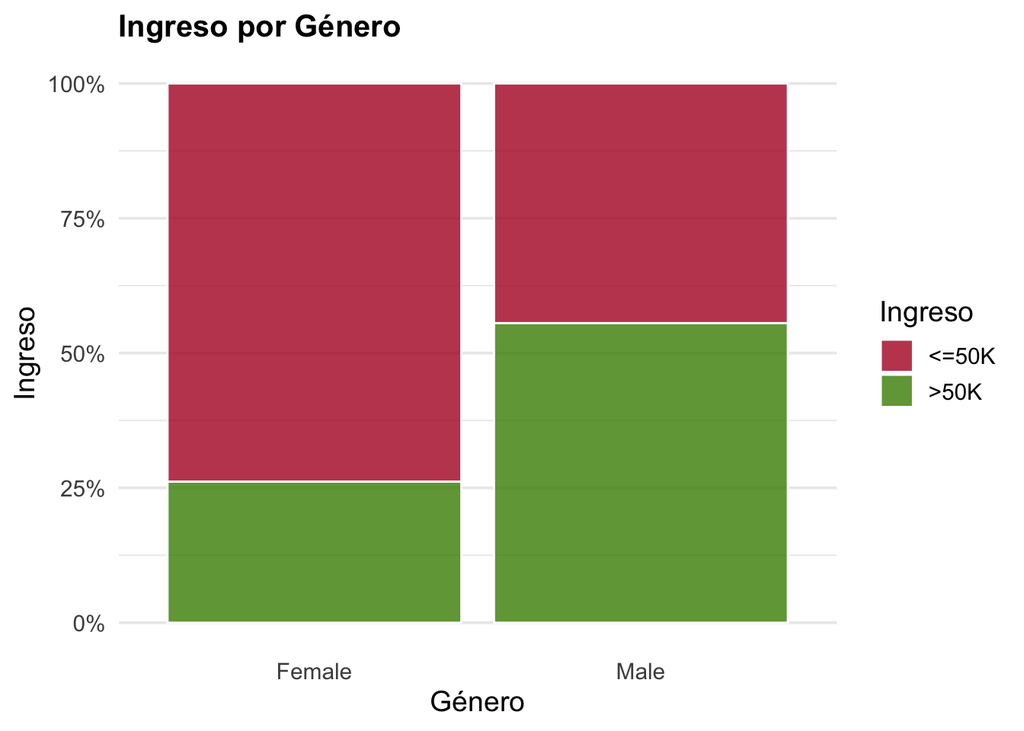

```r
vis_sex <- datos_usa %>%
  ggplot(aes(x = sex, fill = ingreso)) +
  geom_bar(position = "fill", alpha = 0.8, color = "white") +
  scale_fill_manual(values = paleta_income, name = "Ingreso") +
  scale_y_continuous(labels = scales::label_percent()) +
  labs(
    title = "Ingreso por Género",
    x = "Género",
    y = "Ingreso"
  ) +
  theme_minimal(base_size = 14) +
  theme(
    plot.title = element_text(face = "bold", size = 15),
    panel.grid.major.x = element_blank() # Limpiamos la grilla vertical en barras
  )
vis_sex
```

**País nativo vs income (Gráfico de Barras Proporcional)**

```r
# Comprobamos la distribución de ingreso según país nativo
message("Distribución de la variable objetivo según país nativo:")
```

```
Distribución de la variable objetivo según país nativo:
```

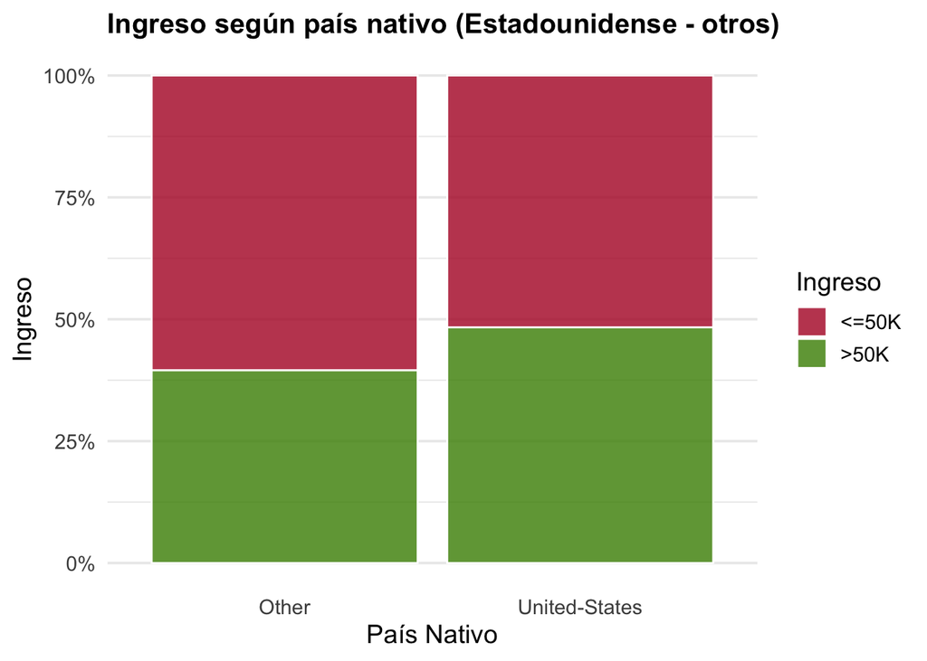

```r
vis_country <- datos_usa %>%
  ggplot(aes(x = native_country, fill = ingreso)) +
  geom_bar(position = "fill", alpha = 0.8, color = "white") +
  scale_fill_manual(values = paleta_income, name = "Ingreso") +
  scale_y_continuous(labels = scales::label_percent()) +
  labs(
    title = "Ingreso según país nativo (Estadounidense - otros)",
    x = "País Nativo",
    y = "Ingreso"
  ) +
  theme_minimal(base_size = 14) +
  theme(
    plot.title = element_text(face = "bold", size = 15),
    panel.grid.major.x = element_blank() # Limpiamos la grilla vertical en barras
  )
vis_country
```

**Raza vs income (Gráfico de Barras Proporcional)**

```r
# Comprobamos la distribución de ingreso según raza
message("Distribución de la variable objetivo según raza:")
```

```
Distribución de la variable objetivo según raza:
```

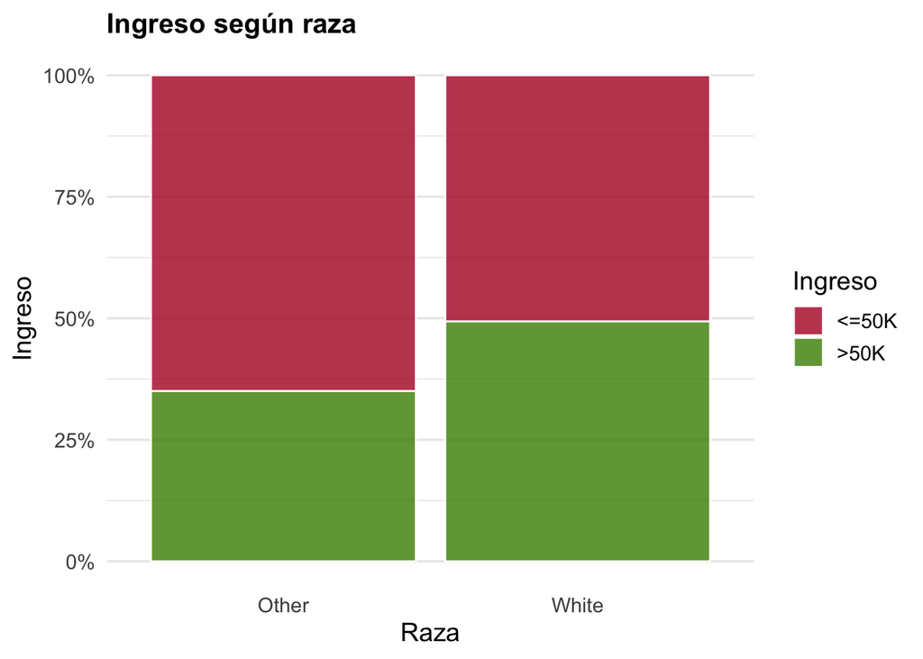

```r
vis_race <- datos_usa %>%
  ggplot(aes(x = race, fill = ingreso)) +
  geom_bar(position = "fill", alpha = 0.8, color = "white") +
  scale_fill_manual(values = paleta_income, name = "Ingreso") +
  scale_y_continuous(labels = scales::label_percent()) +
  labs(
    title = "Ingreso según raza",
    x = "Raza",
    y = "Ingreso"
  ) +
  theme_minimal(base_size = 14) +
  theme(
    plot.title = element_text(face = "bold", size = 15),
    panel.grid.major.x = element_blank() # Limpiamos la grilla vertical en barras
  )
vis_race
```

**Edad vs income (Density Plot)**

```r
# Comprobamos esc. descriptiva de edad segun ingreso
message("Estadistica descriptiva de edad según ingreso:")
```

```
Estadistica descriptiva de edad según ingreso:
```

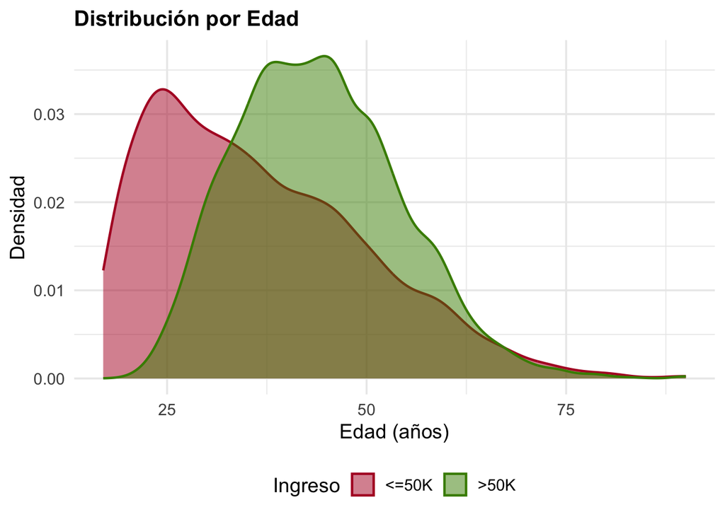

```r
vis_age <- datos_usa %>%
  ggplot(aes(x = age, fill = ingreso, color = ingreso)) +
  geom_density(alpha = 0.5, linewidth = 0.8) +
  scale_fill_manual(values = paleta_income, name = "Ingreso") +
  scale_color_manual(values = paleta_income, name = "Ingreso") +
  labs(
    title = "Distribución por Edad",
    x = "Edad (años)",
    y = "Densidad"
  ) +
  theme_minimal(base_size = 14) +
  theme(
    plot.title = element_text(face = "bold", size = 15),
    legend.position = "bottom"
  )
vis_age
```

**Horas por semana vs income (Violin + Boxplot)**

```r
# Comprobamos esc. descriptiva de horas trabajadas segun ingreso
message("Estadistica descriptiva de horas trabajadas por semana según ingreso:")
```

```
Estadistica descriptiva de horas trabajadas por semana según ingreso:
```

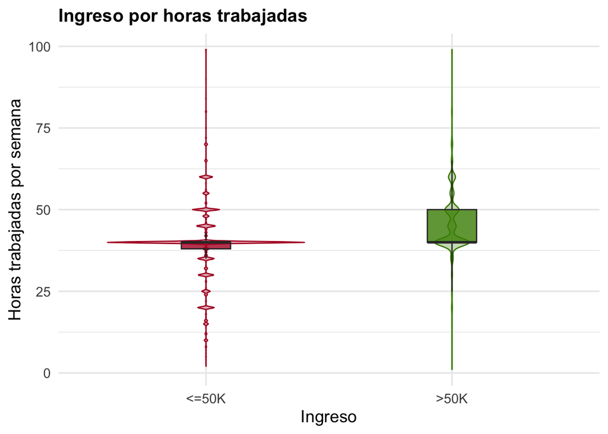

```r
vis_hours <- datos_usa %>%
  ggplot(aes(x = ingreso, y = hours_per_week, fill = ingreso, color = ingreso)) +
  geom_violin(alpha = 0.3, linewidth = 0.5, width = 0.8) +
  geom_boxplot(width = 0.2, alpha = 0.8, color = "gray20", outlier.shape = NA) +
  scale_fill_manual(values = paleta_income, guide = "none") +
  scale_color_manual(values = paleta_income, guide = "none") +
  labs(
    title = "Ingreso por horas trabajadas",
    x = "Ingreso",
    y = "Horas trabajadas por semana"
  ) +
  theme_minimal(base_size = 14) +
  theme(plot.title = element_text(face = "bold", size = 15))
vis_hours
```

```r
message("Chequeamos valores medianos de horas trabajadas por semana")
```

```
Chequeamos valores medianos de horas trabajadas por semana
```

```r
datos_usa %>%
  group_by(ingreso) %>%
  summarise(
    mediana_horas = median(hours_per_week, na.rm = TRUE))
```

| ingreso | mediana_horas |
| --- | --- |
| <=50K | 40 |
| >50K | 40 |

**Horas trabajadas e ingreso según género**

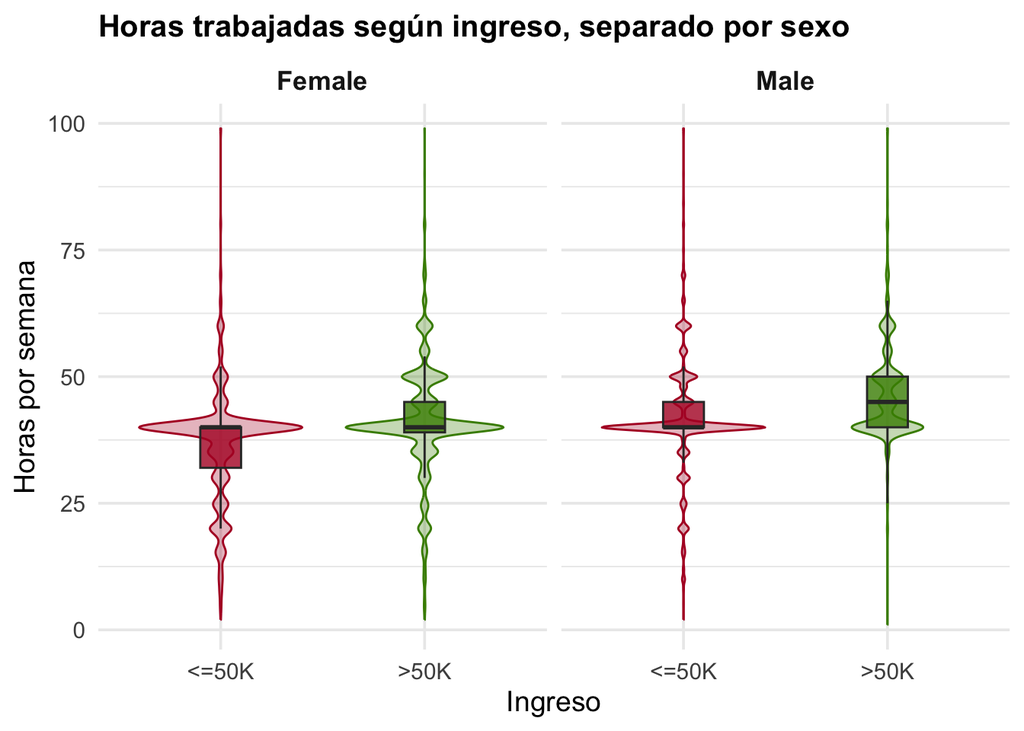

```r
# Justificación visual de la interacción
vis_interaccion <- datos_usa %>%
  ggplot(aes(x = ingreso, y = hours_per_week, fill = ingreso, color = ingreso)) +
  geom_violin(alpha = 0.3, linewidth = 0.5, width = 0.8) +
  geom_boxplot(width = 0.2, alpha = 0.8, color = "gray20", outlier.shape = NA) +
  # Facetamos por sexo para ver si la distribución cambia
  facet_wrap(~sex) +
  scale_fill_manual(values = paleta_income, guide = "none") +
  scale_color_manual(values = paleta_income, guide = "none") +
  labs(
    title = "Horas trabajadas según ingreso, separado por sexo",
    x = "Ingreso",
    y = "Horas por semana"
  ) +
  theme_minimal(base_size = 14) +
  theme(
    plot.title = element_text(face = "bold", size = 15),
    strip.text = element_text(face = "bold", size = 13)
  )

vis_interaccion
```

**Nivel educativo e ingreso según género**

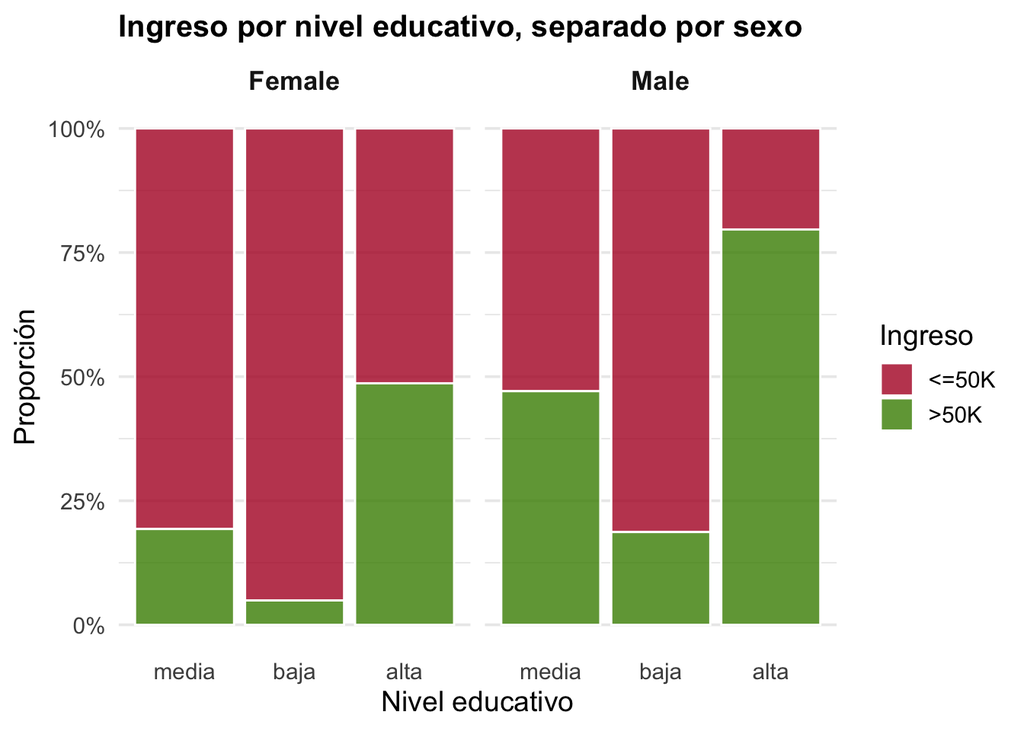

```r
vis_interaccion_edu <- datos_usa %>%
  ggplot(aes(x = nivel_edu, fill = ingreso)) +
  geom_bar(position = "fill", alpha = 0.8, color = "white") +
  facet_wrap(~ sex) +
  scale_fill_manual(values = paleta_income, name = "Ingreso") +
  scale_y_continuous(labels = scales::label_percent()) +
  labs(
    title = "Ingreso por nivel educativo, separado por sexo",
    x = "Nivel educativo",
    y = "Proporción"
  ) +
  theme_minimal(base_size = 14) +
  theme(
    plot.title = element_text(face = "bold", size = 15),
    panel.grid.major.x = element_blank(),
    strip.text = element_text(face = "bold", size = 13)
  )

vis_interaccion_edu
```

### **INTERPRETACIONES DE LAS VISUALIZACIONES BIVARIADAS:**

1. **Nivel educativo:** A mayor nivel educativo, mayor proprocion de ingresos altos. La diferencia es marcada y, en niveles de educación bajos, hay pocas observaciones que superen los 50k de ingresos. Vemos que quienes itenen niveles de educacion alta son los que en mayorita reciben ingresos altos.
2. **Género:** Las mujeres tienen una proporcion de ingresos altos de 25% mientras que los hombres llegan a más de 50%. La brecha pronunciada sugiere que los hombres poseen en promedio más ingresos altos que las mujeres, por lo que podria ser una variable explicativa.
3. **Pais nativo:** Quienes nacieron en Estados Unidos tienen una proporcion de ingresos algo mayor que quienes no pero la diferencia entre ambos grupos no parece ser muy marcada.
4. **Raza:** Dentro del grupo “White”, la proporcion de observaciones que poseen ingresos >50k es mayor que dentro del grupo que incluye otras razas.
5. **Edad:** Las personas con ingresos <=50k se concentran en edades jovenes mientras que quienes tienen ingresos altos (>50k) se concentran en edades adultas.
6. **Horas trabajadas:** La gran mayoria de observaciones con ingresos <=50k trabajan alrededor de 40 hs. Quienes tienen ingresos altos trabajan en promedio más horas.

A partir de las visualizaciones, evaluamos la idea de aplicar transformaciones logaritmicas en las variables continuas age y hours_peer_week pero no lo vimos necesario ya que la visualizacion de age se ve correctamente distribuida y en el caso de hours_peer_week, notamos que la mediana de horas trabajadas por semana es 40hs, lo cual se ve representado en la visulaizacion, por lo tanto tampoco se aplicará transformación logaritmica.

A su vez, notamos que native_country no parecería ser una variable de interés para explicar las diferencias de ingresos ya que las diferencias entre ser estadounidense y ser nativo de otro pais no son visualmente pronunciadas, como si lo son las variables expuestas antes como educación, género o raza.

Asimismo, incluiremos un segundo término de interacción entre sex y nivel_edu, teniendo en cuenta que incluso teniendo niveles altos, las mujeres podrian enfrentarse a menores sueldos que los hombres con ingresos altos debido a barreras estructurales que suceden simplemente por el hecho de ser mujeres. Al realizar la visualización destacamos que efectivamente el patron difiere entre hombres y mujeres y que, aun en educación alta, las mujeres tienen una proporción de ingresos altos menor que los hombres con igual nivel educativo.

# Ajuste de Modelos (Regresión Logística)

### **Categorías de referencia**

Las categorías de referencia seleccionadas fueron, para nivel_edu “media” (al ser la más representativa), para sex “Female”, para race y para native_country “Other”. Estas decisiones ya fueron definidas en la seccion anterior al hacer los factores.

### Modelo base

```r
mod_base <- glm(ingreso ~ nivel_edu + sex + race + native_country + age + hours_per_week, data = datos_usa, family = binomial)
message("Modelo base:")
```

```
Modelo base:
```

```r
summary(mod_base)
```

```
Call:
glm(formula = ingreso ~ nivel_edu + sex + race + native_country +
    age + hours_per_week, family = binomial, data = datos_usa)

Coefficients:
                             Estimate Std. Error z value Pr(>|z|)
(Intercept)                 -5.235724   0.134532 -38.918  < 2e-16 ***
nivel_edubaja               -1.442401   0.082695 -17.442  < 2e-16 ***
nivel_edualta                1.365352   0.041726  32.721  < 2e-16 ***
sexMale                      1.115218   0.045564  24.476  < 2e-16 ***
raceWhite                    0.280882   0.061054   4.601 4.21e-06 ***
native_countryUnited-States  0.112475   0.074176   1.516    0.129
age                          0.050583   0.001625  31.131  < 2e-16 ***
hours_per_week               0.036805   0.001841  19.996  < 2e-16 ***
---
Signif. codes:  0 '***' 0.001 '**' 0.01 '*' 0.05 '.' 0.1 ' ' 1

(Dispersion parameter for binomial family taken to be 1)

    Null deviance: 21821  on 15765  degrees of freedom
Residual deviance: 16859  on 15758  degrees of freedom
AIC: 16875

Number of Fisher Scoring iterations: 4
```

**INTERPRETACIÓN:** En el modelo base podemos ver que todas las variables son significativas (p valor bajo) excepto *native_country* que, como suponiamos en la visualizacion anterior, no es signficativa ya que tiene un p = 0.129 (no podemos afirmar que ser estadounidense tenga un efecto estadisticamente significativo sobre el log-odds de tener ingresos altos, en relacion a la categoria de referencia que es ser no nativo). Con el resto de la variables vemos que la educacion baja reduce el log-odds de ingresos altos (en relacion a la media) y que la educacion alta aumenta los log-odds de ingresos altos (en relacion a la educacion media). A su vez, ser hombre aumenta el log-odds (en relacion a ser mujer), y tanto la edad como las horas trabajadas semanalmente tienen efectos positivos sobre el log-odds. La cuantificacion precisa de estos efectos en probabildiad (y no en chances) se hara en la proxima seccion con AME.

### **Modelo interactivo**

```r
mod_int <- glm(ingreso ~ race + native_country + age + hours_per_week*sex + sex*nivel_edu, data = datos_usa, family = binomial)

message("Modelo con interacción:")
```

```
Modelo con interacción:
```

```r
summary(mod_int)
```

```
Call:
glm(formula = ingreso ~ race + native_country + age + hours_per_week *
    sex + sex * nivel_edu, family = binomial, data = datos_usa)

Coefficients:
                             Estimate Std. Error z value Pr(>|z|)
(Intercept)                 -4.688231   0.181600 -25.816  < 2e-16 ***
raceWhite                    0.276565   0.061098   4.527 5.99e-06 ***
native_countryUnited-States  0.113504   0.074299   1.528   0.1266
age                          0.050489   0.001625  31.075  < 2e-16 ***
hours_per_week               0.023432   0.003583   6.539 6.20e-11 ***
sexMale                      0.365853   0.176961   2.067   0.0387 *
nivel_edubaja               -1.561397   0.240291  -6.498 8.14e-11 ***
nivel_edualta                1.357275   0.080420  16.877  < 2e-16 ***
hours_per_week:sexMale       0.018003   0.004176   4.311 1.62e-05 ***
sexMale:nivel_edubaja        0.139757   0.255321   0.547   0.5841
sexMale:nivel_edualta        0.022375   0.094041   0.238   0.8119
---
Signif. codes:  0 '***' 0.001 '**' 0.01 '*' 0.05 '.' 0.1 ' ' 1

(Dispersion parameter for binomial family taken to be 1)

    Null deviance: 21821  on 15765  degrees of freedom
Residual deviance: 16840  on 15755  degrees of freedom
AIC: 16862

Number of Fisher Scoring iterations: 5
```

**INTERPRETACIÓN:** Al interpretar los resutlados del modelo con interacciones podemos notar que **`sex*nivel_edubaja`** *y* **`sex*nivel_edualta`**no son significativas, por lo que no encontramos evidencia de que el efecto del nviel educativo en las chances de tener ingresos altos difiera según el género. Sin embargo, la interacción **`hours_per_week*sex`** *e*s estadisticamente **significativo** y tiene un coef **positivo** por lo que podemos sugerir que el efecto de la cantidad de horas trabajadas sobre las chances de tener ingresos altos es mayor para los hombres

En relacion al modelo base podemos ver que disminuye la signfiicancia estadistica del género (P= <2e-16 a P = 0.0387), lo que sugiere que parte de su significancia respecto del género sobre el ingreso en el modelo base estaba siendo capturado por las horas de trabajo semanales.

# Efectos marginales

```r
# Calculamos el AME estándar para las var continuas y categóricas
ame_estandar <- avg_slopes(
  mod_int,
  variables = c("race","native_country", "age","hours_per_week", "sex", "nivel_edu"),
  slope = "dydx"
)
message("Calculando AME:")
```

```
Calculando AME:
```

```r
# Lo mostramos en una tabla limpia
ame_estandar |>
  select(term, contrast, estimate, conf.low, conf.high, p.value) |>

  mutate(
    # Multiplicamos por 100 y le pegamos el símbolo % para lectura humana
    estimate_pct = paste0(round(estimate * 100, 2), "%"),
    interpretacion = case_when(
      estimate > 0 & p.value < 0.05 ~ "Aumenta prob. (Sig.)",
      estimate < 0 & p.value < 0.05 ~ "Reduce prob. (Sig.)",
      TRUE ~ "No significativo")
  ) %>%
  select(
    term, contrast, estimate_pct, conf.low, conf.high, p.value, interpretacion) %>%

  rename(
    `Predictor` = term,
    `Contraste` = contrast,
    `Efecto (Prob)` = estimate_pct,
    `IC Inferior` = conf.low,
    `IC Superior` = conf.high,
    `Valor p` = p.value,
    `Interpretación` = interpretacion) %>%

  knitr::kable(
    digits = 4,
    caption = "Efectos Marginales Promedio (Cambio en Probabilidad)") %>%

  kable_styling(
    bootstrap_options = c("striped", "hover", "condensed", "responsive"),
    full_width = FALSE,
    position = "center"
  ) %>%
  # Sombreado azul clarito para las filas significativas
  row_spec(
    row = which(ame_estandar$p.value < 0.05),
    bold = TRUE,
    color = "black",
    background = "#e6f2ff"
  )
```

Efectos Marginales Promedio (Cambio en Probabilidad)

| Predictor | Contraste | Efecto (Prob) | IC Inferior | IC Superior | Valor p | Interpretación |
| --- | --- | --- | --- | --- | --- | --- |
| age | dY/dX | 0.91% | 0.0085 | 0.0096 | 0.0000 | Aumenta prob. (Sig.) |
| hours_per_week | dY/dX | 0.67% | 0.0060 | 0.0073 | 0.0000 | Aumenta prob. (Sig.) |
| native_country | United-States - Other | 2.03% | -0.0057 | 0.0464 | 0.1262 | No significativo |
| nivel_edu | alta - media | 27.1% | 0.2557 | 0.2863 | 0.0000 | Aumenta prob. (Sig.) |
| nivel_edu | baja - media | -24.01% | -0.2614 | -0.2188 | 0.0000 | Reduce prob. (Sig.) |
| race | White - Other | 4.96% | 0.0282 | 0.0711 | 0.0000 | Aumenta prob. (Sig.) |
| sex | Male - Female | 21.46% | 0.1983 | 0.2309 | 0.0000 | Aumenta prob. (Sig.) |

# Forest plot

```r
# Extraemos los coeficientes y calculamos los intervalos manualmente
# para tener control total sobre los niveles (80%, 95%, 99%)
df_plot_or <- broom::tidy(mod_int) |>
  filter(!term %in% c("(Intercept)", "statusquo")) |>
  mutate(
    # Calculamos los límites en log-odds usando cuantiles de la distribución normal
    lo_80 = estimate - qnorm(0.90) * std.error,
    hi_80 = estimate + qnorm(0.90) * std.error,
    lo_95 = estimate - qnorm(0.975) * std.error,
    hi_95 = estimate + qnorm(0.975) * std.error,
    lo_99 = estimate - qnorm(0.995) * std.error,
    hi_99 = estimate + qnorm(0.995) * std.error,

    # Exponenciamos todo para pasarlo a escala de Odds Ratios
    across(c(estimate, starts_with("lo_"), starts_with("hi_")), exp),

    # Etiquetas limpias para el gráfico
    term_clean = case_match(
      term,
      "age" ~ "Edad (Años)",
      "native_countryUnited-States" ~ "País nativo (Estados Unidos vs. Otro",
      "raceWhite" ~ "Raza (Blanco vs. Otro)",
      "sexMale" ~ "Sexo (Hombre vs Mujer)",
      "nivel_edubaja" ~ "Educación (Baja vs. Media)",
      "nivel_edualta" ~ "Educación (Alta vs. Media)",
      "hours_per_week" ~ "Horas por semana",
      "hours_per_week:sexMale" ~ "Interacción: Horas × Hombre",
      "sexMale:nivel_edubaja" ~ "Interacción: Hombre × Edu. Baja",
      "sexMale:nivel_edualta" ~ "Interacción: Hombre × Edu. Alta",
      .default = term # Salvavidas por si queda alguna sin clasificar
    )
  )
message("Graficando OR:")
```

```
Graficando OR:
```

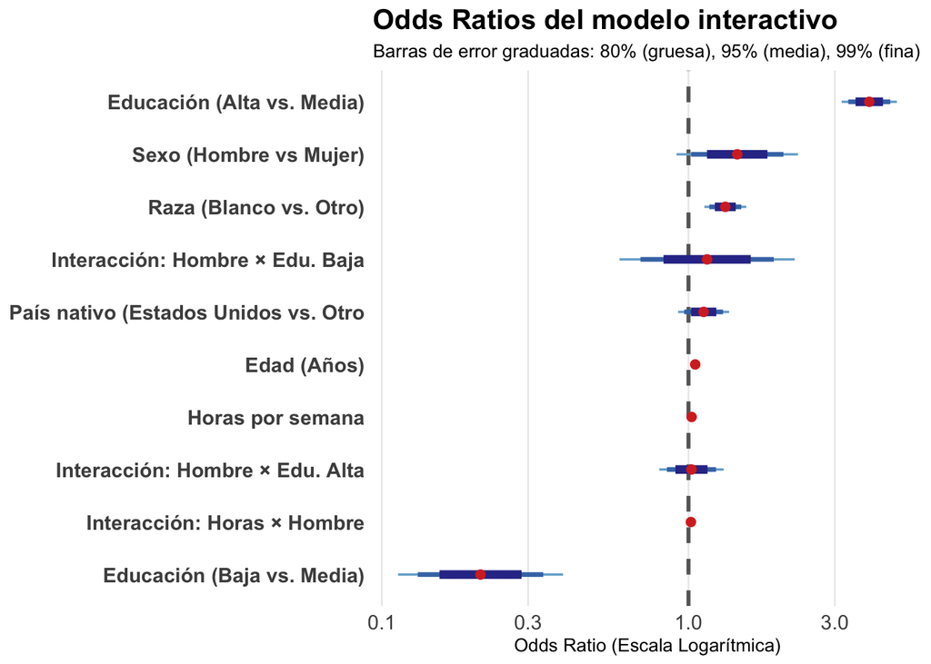

```r
ggplot(df_plot_or, aes(y = reorder(term_clean, estimate), x = estimate)) +
  # Línea vertical de referencia en OR = 1 (Efecto nulo)
  geom_vline(xintercept = 1, linetype = "dashed", color = "gray40", linewidth = 1) +

  # Barra 99% (Fina y clara)
  geom_linerange(aes(xmin = lo_99, xmax = hi_99), color = "#74ADD1",
                 height = 0, linewidth = 0.6) +
  # Barra 95% (Media)
  geom_linerange(aes(xmin = lo_95, xmax = hi_95), color = "#4575B4",
                 height = 0, linewidth = 1.2) +
  # Barra 80% (Gruesa y oscura)
  geom_linerange(aes(xmin = lo_80, xmax = hi_80), color = "#313695",
                 height = 0, linewidth = 2.2) +

  # Punto del estimador central
  geom_point(color = "#D73027", size = 2) +
  scale_x_log10() +

  labs(
    title = "Odds Ratios del modelo interactivo",
    subtitle = "Barras de error graduadas: 80% (gruesa), 95% (media), 99% (fina)",
    x = "Odds Ratio (Escala Logarítmica)",
    y = NULL
  ) +
  theme_minimal(base_size = 10) +
  theme(
    plot.title = element_text(face = "bold", size = 15),
    panel.grid.minor = element_blank(),
    panel.grid.major.y = element_blank(),
    axis.text.y = element_text(face = "bold", size = 11),
    axis.text.x = element_text(size = 11)
  )
```

# Interpretación

- **`sex`** **(male-female):** en promedio, ser hombre aumenta la probabilidad de tener ingresos altos en 21.46 pp. en relacion a ser mujer.
- **`race`** **(white-other):** ser blanco aumenta la probabilidad de tener ingresos altos en 4.96 pp. respecto a otras razas.
- **`nivel_edu`** **(baja-media):** tener educacion baja reduce la probabilidad de tener ingresos altos en 24.01pp respecto a la educación media.
- **`nivel_edu`** **(alta-media):** tener educacion alta aumenta la probabilidad de tener ingresos altos en 27.1pp respecto a la educación media.
- **`hours_peer_week`:** una hora adicional de trabajo por semana aumenta la probabilidad de tener ingresos altos en 0.67pp.
- **`age`:** un año adicional de edad aumenta la probabilidad de tener ingresos altos en 0.91pp.
- **`native_country` (united-states-other):** ser estadounidense en comparacion con ser de otro pais no tiene un efecto estadisticamente significativo sobre la probabilidad de ingresos altos.

Al ver las interacciones, podemos ver que tanto Hombre x nivel_edubaja como *Hombre x nivel_edualta* tienen intervalos de confianza que cruzan 0R = 1, por lo que no podemos afirmar que el efecto del nivel educativo sobre las chances de tener ingresos altos difiera entre hombres y mujeres. Por otro lado, la interaccion horas x hombre tiene un estimador a la derecha de OR = 1 que no cruzan la linea, por lo que podemos afirmar que cada hora trabajada aumenta las chances de tener ingresos altos en hombres mas que en mujeres. Por ultimo, podemos ver que pais nativo cruza OR = 1, reforzando que no es una variable explicativa significativa para el nivel de ingreso.

# Comparación global de modelos

```r
tabla_modelos <- bind_rows(
  broom::glance(mod_base) %>% mutate(Modelo = "1. Sin Interacción"),
  broom::glance(mod_int) %>% mutate(Modelo = "2. Con Interacción")
) %>%
  # Agregamos el cálculo del Pseudo R2 usando la fórmula de McFadden
  mutate(pseudo_r2 = 1 - (deviance / null.deviance)) %>%
  # Seleccionamos las columnas que importan, sacando el BIC
  select(Modelo, null.deviance, deviance, pseudo_r2, AIC, nobs) |>
  # Renombramos las columnas para la tabla final
  rename(
    `Deviance Nula` = null.deviance,
    `Deviance Residual` = deviance,
    `Pseudo-R² (McFadden)` = pseudo_r2,
    `Observaciones` = nobs
  ) %>%
  knitr::kable(
    digits = c(0, 1, 1, 3, 1, 0), # Le damos 3 decimales al Pseudo-R2
    caption = "Comparación Modelo Base vs. Modelo Interactivo"
  ) %>%
  kable_styling(
    bootstrap_options = c("striped", "hover", "condensed", "responsive"),
    full_width = FALSE,
    position = "center"
  ) %>%
  # Resaltamos la fila del modelo ganador
  row_spec(
    row = 2,
    bold = TRUE,
    color = "black",
    background = "#e6f2ff"
  )

tabla_modelos
```

Comparación Modelo Base vs. Modelo Interactivo

| Modelo | Deviance Nula | Deviance Residual | Pseudo-R² (McFadden) | AIC | Observaciones |
| --- | --- | --- | --- | --- | --- |
| 1. Sin Interacción | 21820.6 | 16858.5 | 0.227 | 16874.5 | 15766 |
| 2. Con Interacción | 21820.6 | 16839.6 | 0.228 | 16861.6 | 15766 |

Finalmente, podemos concluir que incluir las interacciones mejora el modelo: Sabiendo que menor AIC indica que un modelo ajusta mejor (16861.6 frente a 16874.5, una diferencia mayor a 10 puntos) y que el pseudo-R2 levemente mejora (de 0.227 a 0.228), entendemos que el modelo con interacciones explica más la variacion en la VD.